# Analysis Code 2

Lorenzo Ricolfi

Link to the pre-registered Research Protocol: https://osf.io/dc5mx

**Review objectives:**

1. Quantify the magnitude and variability of these associations
2. Identify PFAS most strongly linked to specific health outcomes
3. Assess the strength of PFAS–health outcome relationships
4. Evaluate the overall consistency of findings across the evidence base

**Research approach:**

In this meta-meta-analysis, we model meta-analytic estimates from existing meta-analyses. We also model heterogeneity metrics (I-squared) reported by those meta-analyses. In this analysis workflow, we answer to research question 4 within research questions 1, 2, and 3. In other words, every time we assess the magnitude of results we also assess the consistency of results.

# Packages

```r
# tidy
# rm(list=ls())
# Install and load necessary library
pacman::p_load(tidyr,
               dplyr,
               here,
               readr,
               ggplot2,
               gridExtra,
               metafor,
               orchaRd,
               stringr,
               cowplot,
               purrr,
               broom,
               clubSandwich,
               ggrepel,
               kableExtra,
               ggMarginal,
               flextable,
               officer,
               ggExtra,
               forcats
               )
```

# Data loading, wrangling and cleaning

```r
# Load the 'ma_details' and 'ma_e_details' datasets from the 'data' folder using the 'here' package
ma_details <- read.csv(here("data/ma_details.csv"))
ma_e_details <- read.csv(here("data/ma_e_details.csv"))
amstar2 <- read.csv(here("data/amstar2.csv"))
ps_details <- read.csv(here("data/ps_details.csv"))

amstar2 <- amstar2 %>%
  # Remove all columns ending with "Comment"
  select(-ends_with("Comment")) %>%  # Select columns
  # Rename by extracting question numbers
  rename_with(
    ~ case_when(
      . == "ma_id" ~ "ma_id",
      . == "ma_doi" ~ "ma_doi",
      str_detect(., "^Q(\\d+)\\.") ~ paste0("Q", str_extract(., "(?<=^Q)\\d+")),  # Detect pattern matches in strings
      TRUE ~ .
    ),
    .cols = everything()
  ) %>%
  mutate(across(starts_with("Q"), ~ as.numeric(str_extract(., "^\\d+\\.?\\d*"))))  # Create/modify columns

# Creating a data set for qualitative synthesis (i.e., dat_qual)
# Filter and clean 'ma_e_details', then join with 'ma_details'
dat_qual <- ma_e_details %>%
  # Keep only rows where chemical class is PFAS
  filter(chemical_class == "PFAS") %>%  # Filter rows by conditions
  # Standardize naming of effect size measures
  mutate(ma_es_measure = recode(
    ma_es_measure,
    "? (regression coefficient) value" = "Beta (regression coefficient) value",
    "beta (regression coefficient) value" = "Beta (regression coefficient) value",
    "Adjusted ? (regression coefficient)" = "Beta (regression coefficient) value",
    "adjusted coefficient regression (?)" = "Beta (regression coefficient) value",
    "relative risk" = "Risk ratio",
    "RR (risk ratio)" = "Risk ratio",
    "OR (odds ratio)" = "Odds ratio",
    "fishers z" = "Fisher's Z",
    "log OR (odds ratio)" = "log Odds ratio")) %>%
  # Standardize naming of chemical identifiers
  mutate(chemical_id = recode(
    chemical_id,
    "n-PFOA" = "PFOA",
    "n-PFOS" = "PFOS",
    "PFHsX" = "PFHxS")) %>%
  mutate(I_squared = as.numeric(I_squared)) %>%
  #mutate(I_squared = if_else(model == "fixed effects model" & I_squared == 0, NA_real_, I_squared)) %>%
  # Merging 'ma_details' and 'ma_e_details' using the common key 'ma_id'
  left_join(ma_details, by = "ma_id", suffix = c("", ".remove")) %>%  # Join tables keeping all rows from the left table
  select(-ends_with(".remove")) %>%
  # Removing excluded studies
  filter(status != "excluded") %>%
  mutate(ma_journal = tolower(ma_journal),
         ma_journal = gsub("^\\s+|\\s+$", "", ma_journal)) %>%
  left_join(amstar2, by = "ma_id", suffix = c("", ".remove"))

ps_details <- ps_details %>%
  filter(chemical_class == "PFAS") %>%
  select("ma_e_id", "ma_id", "primary_doi", "chemical")
```

# Effect size conversion

To address the challenge of different effect size metrics reported across the included meta-analyses, we developed a conversion function (*convert_to_logOR()*) to standardize all effect sizes to the log odds ratio (lnOR) scale.

This function systematically converted odds ratios, standardized mean differences, risk ratios (with or without baseline risk adjustment), Fisher’s z values, and logistic regression coefficients to lnOR values, based on established methodological approximations (e.g., Borenstein et al. 2021).

```r
# Define a conversion function with an optional baseline risk parameter
convert_to_logOR <- function(effect_measure, point_estimate, ma_l_ci, ma_u_ci, regression_type = NA, baseline_risk = NA) {
  # Ensure the effect measure is treated as character
  effect_measure <- as.character(effect_measure)
  # Ensure point estimate, lower CI, and upper CI are numeric
  point_estimate <- suppressWarnings(as.numeric(as.character(point_estimate)))
  ma_l_ci <- suppressWarnings(as.numeric(as.character(ma_l_ci)))
  ma_u_ci <- suppressWarnings(as.numeric(as.character(ma_u_ci)))

  # Conversion for Odds ratio and log Odds ratio
  if (effect_measure == "Odds ratio") {
    # Convert OR to logOR
    return(c(log(point_estimate), log(ma_l_ci), log(ma_u_ci)))

  } else if (effect_measure == "log Odds ratio") {
    # Already in logOR
    return(c(point_estimate, ma_l_ci, ma_u_ci))

    # Conversion for SMD (standardized mean difference)
  } else if (effect_measure == "SMD (standardized mean difference)") {
    # Following Borenstein et al. (2021): logOR = SMD * pi/sqrt(3)
    logOR_point_estimate <- point_estimate * (pi / sqrt(3))

    # Convert lower and upper confidence intervals using the same logic
    logOR_l_ci <- ma_l_ci * (pi / sqrt(3))
    logOR_u_ci <- ma_u_ci * (pi / sqrt(3))

    return(c(logOR_point_estimate, logOR_l_ci, logOR_u_ci))

    # Conversion for Relative risk / Risk ratio with optional baseline risk
  } else if (effect_measure == "Risk ratio") {
    if (!is.na(baseline_risk)) {
      # Using the conversion: OR = RR * (1-p0) / (1-RR*p0)
      OR <- point_estimate * (1 - baseline_risk) / (1 - point_estimate * baseline_risk)
      OR_l_ci <- ma_l_ci * (1 - baseline_risk) / (1 - ma_l_ci * baseline_risk)
      OR_u_ci <- ma_u_ci * (1 - baseline_risk) / (1 - ma_u_ci * baseline_risk)
      return(c(log(OR), log(OR_l_ci), log(OR_u_ci)))
    } else {
      # If no baseline risk is provided, fallback to the approximation:
      return(c(log(point_estimate), log(ma_l_ci), log(ma_u_ci)))
    }

    # Conversion for Fisher's z (often used for correlations)
  } else if (grepl("fishers z", effect_measure, ignore.case = TRUE)) {
    # Convert z to correlation, then to logOR.
    # r = tanh(z)
    # Approximation: logOR = r * pi/sqrt(3)
    r <- tanh(point_estimate)
    return(r * (pi / sqrt(3)))

    # Conversion for regression coefficients assumed from logistic regression:
  } else if (effect_measure %in% c("Beta (regression coefficient) value")) {
    # Check if regression_type is 'logistic'
    if (!is.na(regression_type) && regression_type == "logistic") {
      return(c(point_estimate, ma_l_ci, ma_u_ci))
    } else {
      return(rep(NA, 3)) # Not logistic regression, cannot convert
    }
  } else {
    warning("Effect measure conversion not implemented for: ", effect_measure)
    return(rep(NA, 3)) # Return NA for all three
  }
}
```

# Effect size calculation

```r
# conversion function to transform effect size metrics into logOR
source(here("Rdata/functions", "conversion.R"))

# Creating a data set for quantitative synthesis (i.e., dat_quant)
# Apply conversion to each row
dat_quant <- dat_qual %>%
  # Apply operations row by row instead of column-wise
  rowwise() %>%
  mutate(
    # Convert various effect size measures to log odds ratios using the custom function
    converted = list(convert_to_logOR(ma_es_measure, ma_point_estimate,
                                     ma_l_ci, ma_u_ci, regression_type, 0.1)),
     # Extract the log odds ratio point estimate from the conversion result
    logOR = converted[1],
    # Extract the lower bound of the log odds ratio confidence interval
    l_ci_logOR = converted[2],
    # Extract the upper bound of the log odds ratio confidence interval
    u_ci_logOR = converted[3]
  ) %>%
  # Return to regular (non-rowwise) tibble structure
  ungroup() %>%
  # Remove the temporary 'converted' list column
  select(-converted) %>%
  # Keep only rows where the log odds ratio was successfully calculated
  filter(!is.na(logOR))
```

# Testing the impact of our conversion strategy

We assessed whether the original effect size metric (ma_es_measure in the following model) influenced the meta-meta-analysis results by including it as a moderator in a multilevel meta-analytic model (random effects: meta-analysis ID and effect size ID).

```r
dat_quant <- dat_quant %>%
  mutate(pair = paste0(health_outcome_group, chemical_id)) # The new variable 'pair' will be used as cluster in the impute_covariance_matrix() function, effectively creating a variance-covariance matrix.

# custom function
source(here("Rdata/functions", "build_vcv_from_overlap.R"))

# Build VCV using observed overlap of primary studies (global across all estimates)
vcv_obj <- build_vcv_from_overlap(
  dat_sub    = dat_quant,
  ps_details = ps_details,
  id_col     = "ma_e_id",
  vi_col     = "se"
)

VCV_test <- vcv_obj$V
dat_quant_test <- vcv_obj$dat_vcv
```

```r
mod_test <- rma.mv(yi = logOR,  # Fit a multilevel/multivariate meta-analysis model
              V = VCV_test,
              random = list(~1|ma_id,
                            ~1|ma_e_id),
              mods = ~ ma_es_measure - 1,
              data = dat_quant_test,
              test = "t",
              sparse = TRUE)

save(mod_test, file = here("Rdata", "models/mod_test.RData"))
```

[output not shown]

```r
ggsave(here("Rdata/figures/supplements","Supplementary Figure 1.png"),
       plot = orc_plot_test,
       width = 7,
       height = 6)
```

# Overview of the Dataset

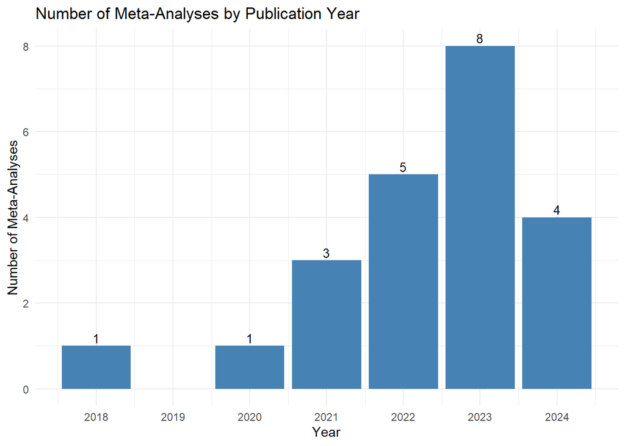

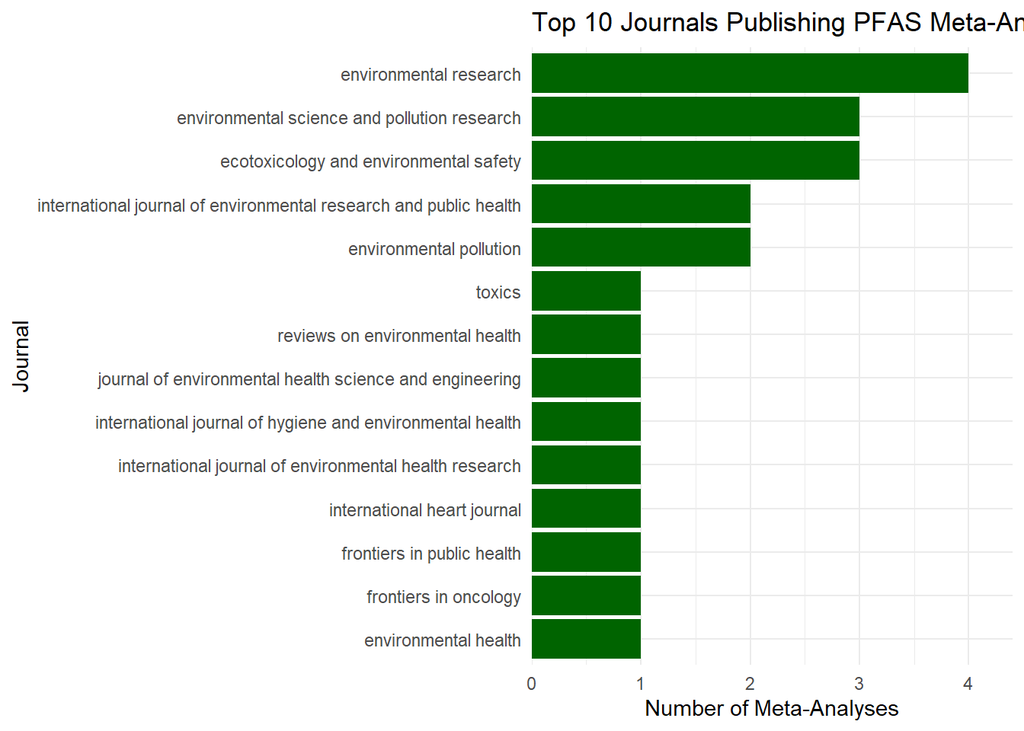

Table: Chemicals in Meta-Analyses

| Chemical | Number of meta-analyses | Number of health outcomes | Number of health outcome groups | Number of meta-analytic estimates |
| --- | --- | --- | --- | --- |
| PFOA | 22 | 22 | 7 | 40 |
| PFOS | 22 | 26 | 10 | 44 |
| PFHxS | 21 | 24 | 10 | 41 |
| PFNA | 21 | 24 | 10 | 41 |
| PFDA | 12 | 15 | 6 | 24 |
| PFUnDA | 9 | 7 | 4 | 11 |
| PFHpA | 5 | 7 | 3 | 9 |
| PFDoDA | 4 | 6 | 3 | 9 |
| PFAS | 2 | 13 | 4 | 13 |
| PFBS | 2 | 4 | 1 | 5 |
| PFHpS | 1 | 1 | 1 | 1 |
| PFOSA-AcOH | 1 | 1 | 1 | 1 |
| PFTrDA | 1 | 1 | 1 | 1 |

Table: Health Outcomes in Meta-Analyses

| Outcome | Number of meta-analyses | Number of chemicals | Number of meta-analytic estimates |
| --- | --- | --- | --- |
| breast cancer | 4 | 10 | 23 |
| gestational diabetes mellitus | 4 | 10 | 32 |
| hypertension | 3 | 6 | 22 |
| preeclampsia | 3 | 9 | 23 |
| preterm birth | 3 | 9 | 19 |
| attention deficit hyperactivity disorder (ADHD) | 2 | 5 | 9 |
| gestational hypertension | 2 | 8 | 13 |
| miscarriage | 2 | 5 | 10 |
| allergic rhinitis | 1 | 4 | 4 |
| asthma | 1 | 4 | 4 |
| atopic dermatitis | 1 | 4 | 4 |
| autismspectrum disorder (ASD) | 1 | 4 | 4 |
| eczema | 1 | 4 | 4 |
| fecundability | 1 | 5 | 5 |
| gastointestinal tract cancer (GIC) | 1 | 3 | 3 |
| genitourinary cancer | 1 | 6 | 6 |
| hematologic cancer | 1 | 1 | 1 |
| hypertensive disorders of pregnancy (HDP) | 1 | 8 | 8 |
| hyperuricemia | 1 | 5 | 5 |
| infertility | 1 | 5 | 5 |
| low birth weight | 1 | 2 | 2 |
| lung cancer | 1 | 1 | 1 |
| osteoporosis | 1 | 4 | 4 |
| risk of metabolic syndrome | 1 | 4 | 4 |
| risk of overweight | 1 | 1 | 1 |
| risk of total cancer | 1 | 7 | 7 |
| skin cancer | 1 | 1 | 1 |
| small for gestational age (SGA) | 1 | 7 | 7 |
| thyroid cancer | 1 | 5 | 5 |
| wheeze | 1 | 4 | 4 |

Table: Health Outcomes Groups in Meta-Analyses

| Outcome group | Number of meta-analyses | Number of health outcomes | Number of meta-analytic estimates |
| --- | --- | --- | --- |
| Pregnancy, childbirth or the puerperium | 7 | 10 | 96 |
| Certain conditions originating in the perinatal period | 4 | 9 | 28 |
| Neoplasms | 4 | 10 | 47 |
| Diseases of the circulatory system | 3 | 6 | 22 |
| Endocrine, nutritional or metabolic diseases | 3 | 5 | 10 |
| Mental, behavioural or neurodevelopmental disorders | 2 | 5 | 13 |
| Diseases of the musculoskeletal system or connective tissue | 1 | 4 | 4 |
| Diseases of the respiratory system | 1 | 4 | 8 |
| Diseases of the skin | 1 | 4 | 8 |
| Symptoms, signs or clinical findings, not elsewhere classified | 1 | 4 | 4 |

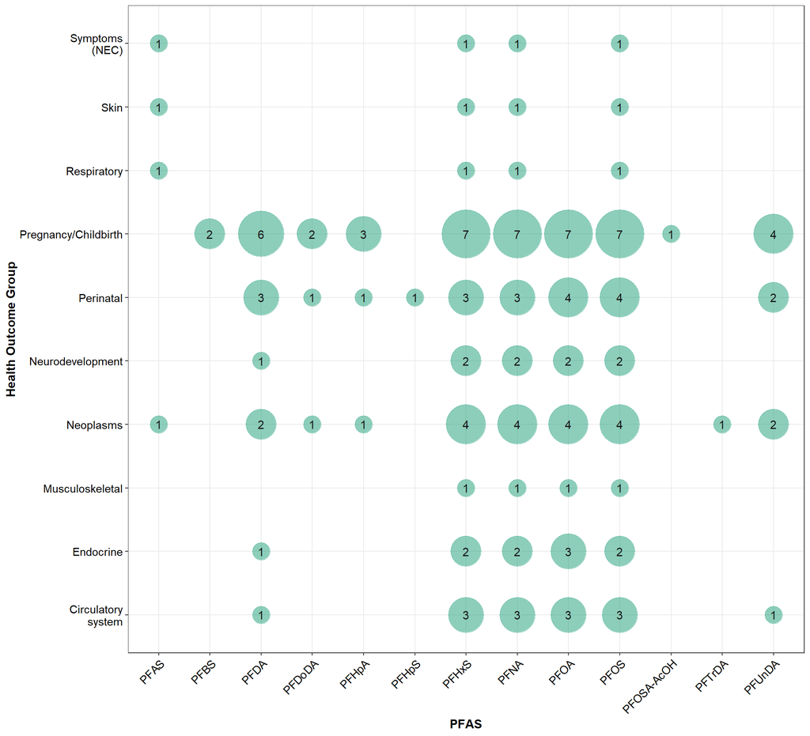

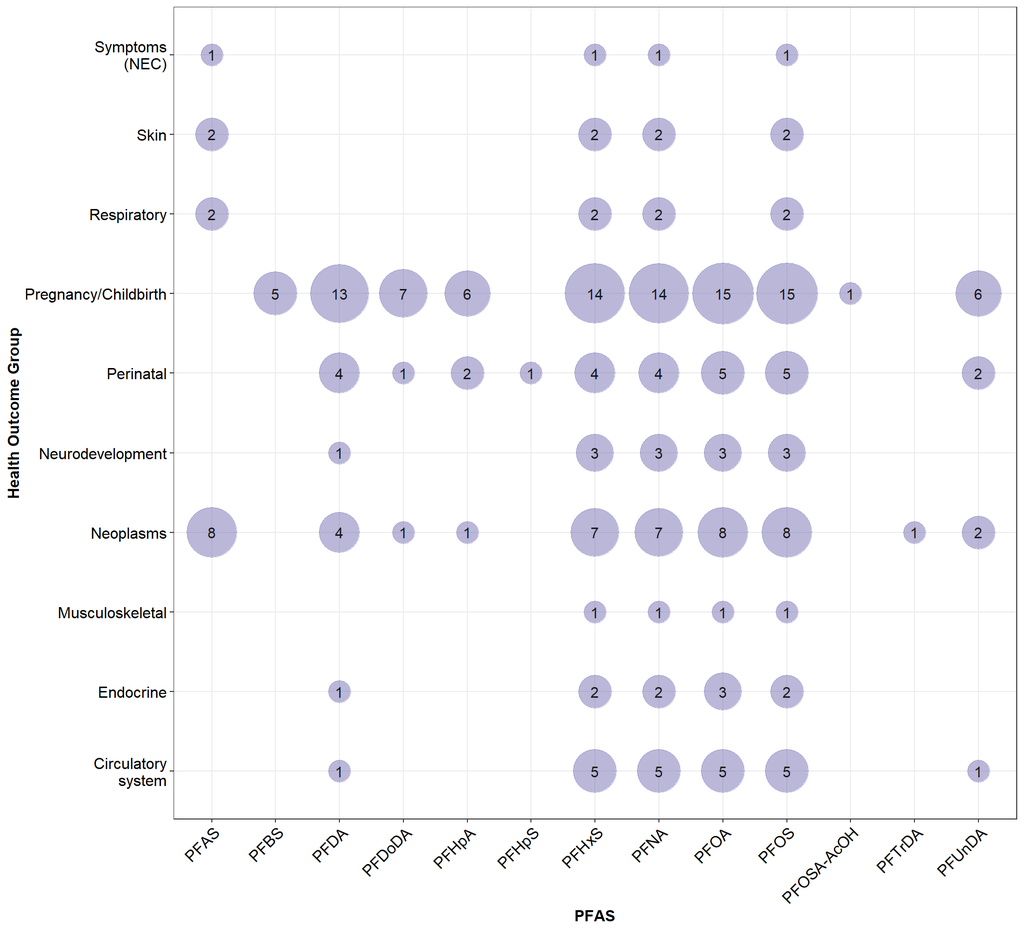

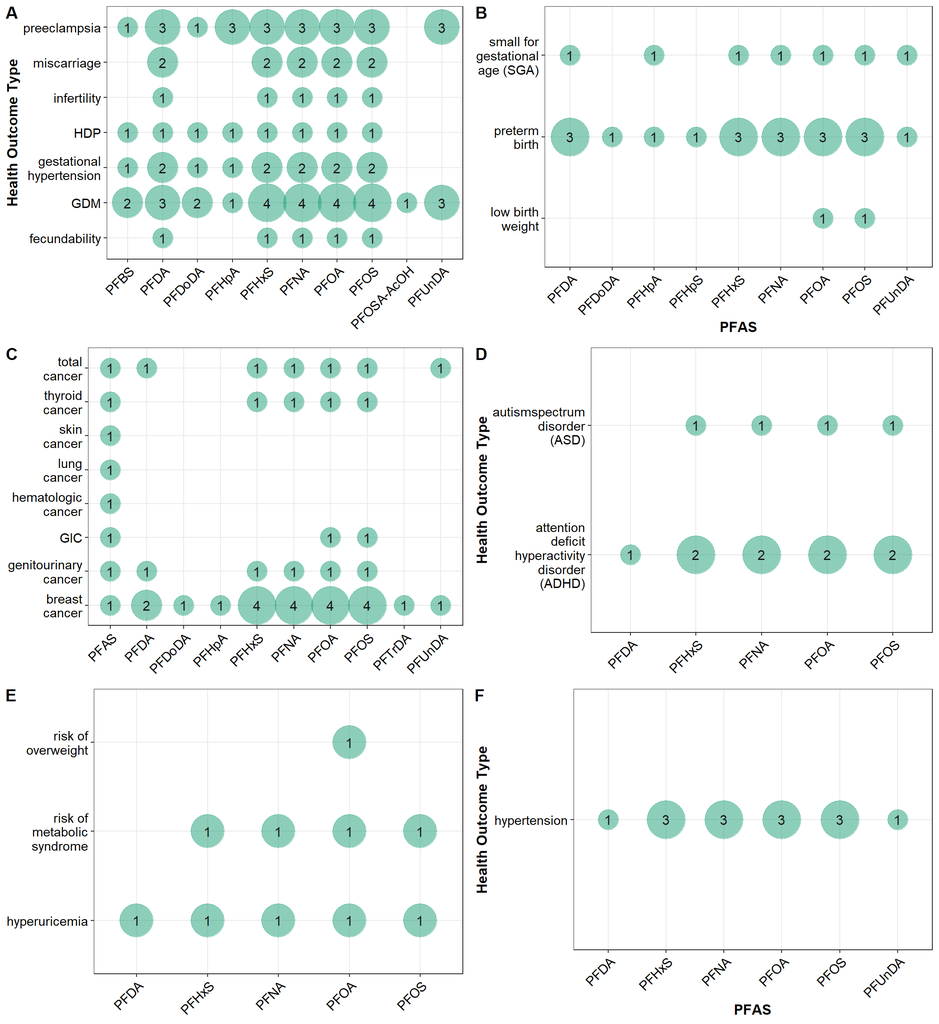

# First Research Question

**Question:** How does exposure to per- and polyfluoroalkyl substances (PFAS) affect human health?

**Objective:** To evaluate the magnitude and variability of associations between PFAS exposure and adverse human health outcomes based on multiple meta-analyses.

## The Overall Result

Our meta-meta-analytic approach addressed heterogeneity at two levels. First, we modeled between-meta-analysis heterogeneity in reported effect sizes (logOR) using a multilevel meta-analytic model. This allowed us to partition the variance in outcomes across and within meta-analyses. Second, we meta-analyzed heterogeneity as the outcome by synthesizing the I² values reported by the included meta-analyses. These were transformed into ln(H) to quantify and model differences in the internal heterogeneity of primary studies.

Random effect structure:

- **~1 | ma_id** introduces a random intercept for each meta-analysis. It acknowledges that different meta-analyses may have different baseline effects due to design, populations, etc.
- **~1 | ma_e_id** introduces a random intercept for each effect size estimate within a meta-analysis. It accounts for non-independence of estimates within the same meta-analysis.

```r
# 1) Make sure the estimate id and variances are aligned
dat_vcv <- dat_quant %>%
  mutate(
    estimate_id = ma_e_id,
    vi = se^2
  ) %>%
  arrange(estimate_id) %>%
  mutate(row_id = row_number())

# 2) Build sparse incidence matrix A: (estimate_id x primary_doi)
ps_long <- ps_details %>%
  transmute(
    estimate_id = ma_e_id,
    primary_doi = primary_doi
  ) %>%
  distinct()

# Keep only DOIs for estimates that are actually in the model dataset
ps_long <- ps_long %>%
  semi_join(dat_vcv %>% select(estimate_id), by = "estimate_id")

# Integer indices for sparseMatrix()
i_idx <- match(ps_long$estimate_id, dat_vcv$estimate_id)
doi_levels <- sort(unique(ps_long$primary_doi))
j_idx <- match(ps_long$primary_doi, doi_levels)

A <- sparseMatrix(
  i = i_idx,
  j = j_idx,
  x = 1,
  dims = c(nrow(dat_vcv), length(doi_levels)),
  dimnames = list(dat_vcv$estimate_id, doi_levels)
)

# 3) Shared primary-study counts (sparse)
shared <- tcrossprod(A)  # n_ij = number of shared DOIs

# 4) n_i (number of DOIs per estimate)
n_i <- Matrix::rowSums(A)

# 5) Build rho matrix ONLY where shared > 0 (keep sparse)
# cosine overlap: rho_ij = n_ij / sqrt(n_i * n_j)
# We'll compute elementwise on the non-zero entries of `shared`.
shared_t <- summary(shared)  # triplet form: i, j, x

denom <- sqrt(n_i[shared_t$i] * n_i[shared_t$j])
rho_x <- ifelse(denom > 0, shared_t$x / denom, 0)

rho <- sparseMatrix(
  i = shared_t$i,
  j = shared_t$j,
  x = rho_x,
  dims = dim(shared),
  dimnames = dimnames(shared)
)

# Ensure diagonal rho = 1 for estimates with >=1 DOI, else 0
diag(rho) <- ifelse(n_i > 0, 1, 0)

# 6) Convert rho to VCV: V_ij = rho_ij * sqrt(vi_i * vi_j)
vi <- dat_vcv$vi
shared_rho_t <- summary(rho)

vcv_x <- shared_rho_t$x * sqrt(vi[shared_rho_t$i] * vi[shared_rho_t$j])

VCV <- sparseMatrix(
  i = shared_rho_t$i,
  j = shared_rho_t$j,
  x = vcv_x,
  dims = dim(rho),
  dimnames = dimnames(rho)
)

# Guarantee exact diagonal equals vi (metafor likes this)
diag(VCV) <- vi

# (Optional but often good) force symmetry
VCV <- forceSymmetric(VCV, uplo = "L")
```

```r
# 7) Fit model
mod_overall <- rma.mv(
  yi = logOR,
  V  = VCV,
  random = list(~1 | ma_id,
                ~1 | ma_e_id),
  data = dat_vcv,
  test = "t",
  sparse = TRUE
)

save(mod_overall, file = here("Rdata/models", "mod_overall.RData"))
```

```r
# 1. Calculate H², lnH², and SElnH
dat_lnH <- dat_quant %>%
  mutate(k = if_else(is.na(n_ps_e), n_ps, n_ps_e)) %>% #For each row, checks if n_ps_e (i.e., number of primary study estimates) is NA. If it is, replaces it with the value from n_ps (number of primary studies).
  filter(k > 2) %>%  # Explicitly exclude cases where SElnH would be invalid
  mutate(
    I_squared = as.numeric(I_squared),
    # Calculate I² as a proportion
    I_squared_prop = I_squared / 100,
    # Calculate H² from I²
    H2 = 1 / (1 - I_squared_prop),
    lnH = log(sqrt(H2)),

    # Ensure Q is available — calculate from H² and k
    Q = H2 * (k - 1),

    # Compute SElnH using different formulas based on whether Q > k according to Higging & Thompson 2002
    SElnH = case_when(
      Q > k ~ 0.5 * ((log(Q) - log(k - 1)) / (sqrt(2 * Q) - sqrt(2 * k - 3))),
      TRUE ~ sqrt((1 / (2 * (k - 2))) * (1 - (1 / (3 * (k - 2))^2)))
    ),

    # Calculate Confidence Intervals for lnH
    lnH_ci_lower = lnH - 1.96 * SElnH,
    lnH_ci_upper = lnH + 1.96 * SElnH
  ) %>%
  filter(!is.infinite(lnH)) %>% # removing lnH = Inf (it happens when I-squared = 0)
  group_by(chemical_id) %>%
  filter(n_distinct(ma_e_id) > 1) %>% # at least 2 meta-analytic estimates
  ungroup() %>%
  mutate(chemical_id = droplevels(factor(chemical_id)))

# Create the VCV matrix assuming rho = 0.5 for within-pair correlation
dat_lnH <- dat_lnH[!is.na(dat_lnH$lnH),]

dat_lnH_vcv <- dat_lnH %>%
  mutate(
    estimate_id = ma_e_id,
    vi = SElnH^2
  ) %>%
  arrange(estimate_id) %>%
  mutate(row_id = row_number())

ps_long_lnH <- ps_details %>%
  transmute(
    estimate_id = ma_e_id,
    primary_doi = primary_doi
  ) %>%
  distinct() %>%
  semi_join(dat_lnH_vcv %>% select(estimate_id), by = "estimate_id")

i_idx <- match(ps_long_lnH$estimate_id, dat_lnH_vcv$estimate_id)
doi_levels <- sort(unique(ps_long_lnH$primary_doi))
j_idx <- match(ps_long_lnH$primary_doi, doi_levels)

A <- sparseMatrix(
  i = i_idx,
  j = j_idx,
  x = 1,
  dims = c(nrow(dat_lnH_vcv), length(doi_levels)),
  dimnames = list(dat_lnH_vcv$estimate_id, doi_levels)
)

shared <- tcrossprod(A)
n_i <- Matrix::rowSums(A)

shared_t <- summary(shared)
denom <- sqrt(n_i[shared_t$i] * n_i[shared_t$j])
rho_x <- ifelse(denom > 0, shared_t$x / denom, 0)

rho <- sparseMatrix(
  i = shared_t$i,
  j = shared_t$j,
  x = rho_x,
  dims = dim(shared),
  dimnames = dimnames(shared)
)

diag(rho) <- ifelse(n_i > 0, 1, 0)

vi <- dat_lnH_vcv$vi
rho_t <- summary(rho)

VCV_lnH <- sparseMatrix(
  i = rho_t$i,
  j = rho_t$j,
  x = rho_t$x * sqrt(vi[rho_t$i] * vi[rho_t$j]),
  dims = dim(rho),
  dimnames = dimnames(rho)
)

diag(VCV_lnH) <- vi
VCV_lnH <- forceSymmetric(VCV_lnH, uplo = "L")
```

```r
mod_overall_lnH <- rma.mv(
  yi = lnH,
  V = VCV_lnH,
  random = list(~1|ma_id,
                ~1|ma_e_id),
  data = dat_lnH,
  test = "t"
)

save(mod_overall_lnH, file = here("Rdata/models", "mod_overall_lnH.RData"))
```

```r
#Extracting data from the model
overall_results_H2 <- tibble(
  lnH = as.numeric(mod_overall_lnH$b),
  lnH_ci_lower = mod_overall_lnH$ci.lb,
  lnH_ci_upper = mod_overall_lnH$ci.ub,
  lnH_p_value = mod_overall_lnH$pval
) %>%
  mutate(
    # 1) Compute H2 and its CIs
    H2        = exp(2 * lnH),
    H2_lb     = exp(2 * lnH_ci_lower),
    H2_ub     = exp(2 * lnH_ci_upper),

    # 2) Convert to I2 and truncate to [0,100]
    I2           = pmin(100, pmax(0, (H2 - 1)/H2  * 100)),
    I2_ci_lower  = pmin(100, pmax(0, (H2_lb - 1)/H2_lb * 100)),
    I2_ci_upper  = pmin(100, pmax(0, (H2_ub - 1)/H2_ub * 100))
  )

I2_text <- paste0("I² = ", round(overall_results_H2$I2, 1),
                  "% [", round(overall_results_H2$I2_ci_lower, 1),
                  "–", round(overall_results_H2$I2_ci_upper, 1), "%]")
```

```
## `height` was translated to `width`.
## `height` was translated to `width`.
```

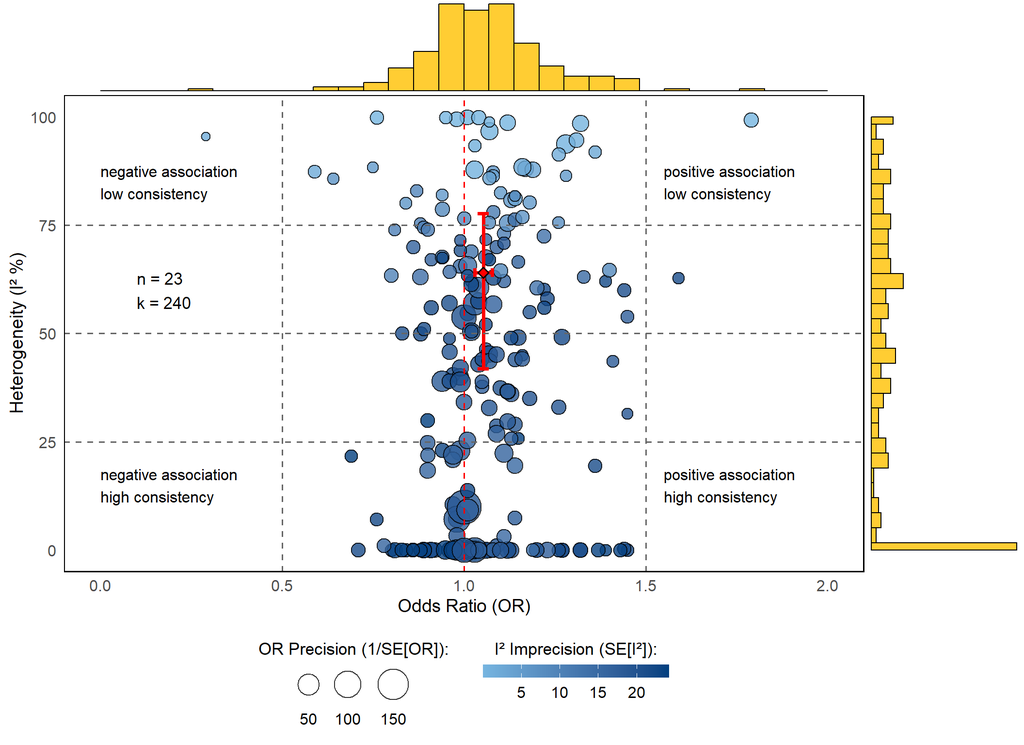

```r
# Prepare merged dataset for plotting (merge OR and I2 data by ma_e_id)
galaxy_data <- dat_quant %>%
  mutate(
    OR = exp(logOR),
    OR_ci_lower = exp(l_ci_logOR),
    OR_ci_upper = exp(u_ci_logOR)
  ) %>%
  left_join(
    dat_lnH %>% select(ma_e_id, I2, I2_ci_lower, I2_ci_upper, I2_se),
    by = "ma_e_id"
  ) %>%
  filter(!is.na(I2) & !is.na(OR))

# Prepare overall result
overall_point <- data.frame(
  OR = overall_value_logOR$OR,
  OR_ci_lower = overall_value_logOR$OR_ci_lower,
  OR_ci_upper = overall_value_logOR$OR_ci_upper,
  I2 = overall_value_I2$I2,
  I2_ci_lower = overall_value_I2$I2_ci_lower,
  I2_ci_upper = overall_value_I2$I2_ci_upper,
  ma_e_id = "Overall"
)

# Calculations for prediction intervals (logOR)
# Extract model components
mu <- as.numeric(mod_overall$b)  # overall effect size (log OR)
se <- mod_overall$se             # standard error
tau2 <- sum(mod_overall$sigma2)  # total between-study variance
k <- length(mod_overall$yi)      # number of effect sizes
df <- k - length(mod_overall$sigma2)  # conservative degrees of freedom

# Calculate t critical value
t_crit <- qt(0.975, df = df)

# Calculate prediction interval (on log scale)
pred_lower <- mu - t_crit * sqrt(tau2 + se^2)
pred_upper <- mu + t_crit * sqrt(tau2 + se^2)

# Convert to OR scale
pred_int <- data.frame(
  OR_pred_lower = exp(pred_lower),
  OR_pred_upper = exp(pred_upper),
  OR = overall_point$OR
)

# Calculations for prediction intervals (lnH)
# Extract model components
mu_lnH <- as.numeric(mod_overall_lnH$b)    # overall effect size (lnH)
se_lnH <- mod_overall_lnH$se               # standard error
tau2_lnH <- sum(mod_overall_lnH$sigma2)    # total between-study variance
k_lnH <- length(mod_overall_lnH$yi)        # number of effect sizes
df_lnH <- k_lnH - length(mod_overall_lnH$sigma2)  # conservative degrees of freedom

# Calculate t critical value
t_crit_lnH <- qt(0.975, df = df_lnH)

# Prediction interval on log scale
pred_lower_H2 <- mu_lnH - t_crit_lnH * sqrt(tau2_lnH + se_lnH^2)
pred_upper_H2 <- mu_lnH + t_crit_lnH * sqrt(tau2_lnH + se_lnH^2)

# Convert to I-squared scale
pred_int_I2 <- data.frame(
  I2_pred_lower = pmin(100, pmax(0, (exp(2 * pred_lower_H2[1]) - 1)/exp(2 * pred_lower_H2[1])  * 100)),
  I2_pred_upper = pmin(100, pmax(0, (exp(2 * pred_upper_H2[1]) - 1)/exp(2 * pred_upper_H2[1])  * 100)),
  I2 = pmin(100, pmax(0, (exp(2 * mu_lnH[1]) - 1)/exp(2 * mu_lnH[1])  * 100))
)
```

**Figure 1. Overall association and consistency of PFAS-related adverse health outcomes across meta-analyses.** *Each blue circle represents the combination of a meta-analytic effect size and associated heterogeneity measure from 23 published meta-analyses on PFAS exposure and human health outcomes. The x-axis shows the pooled odds ratio (OR), where values above 1 indicate increased odds of adverse outcomes. The y-axis depicts heterogeneity (I²), representing the percentage of variation across studies not due to chance. Bubble sizes are scaled by OR’s precision (inverse of standard error), and the colour gradient is according to I²’s imprecision (standard error). The black diamond filled in red indicates the overall pooled estimate from a meta-meta-analysis, with red horizontal and vertical error bars showing its 95% confidence intervals for OR and I², respectively. Grey dashed lines indicate thresholds for heterogeneity and OR. Quadrant annotations help interpret the strength and consistency of associations. The yellow histogram at the top and the yellow histogram on the right represent data distributions of odds ratios and heterogeneity measures, respectively. An explanation for the large number of I2 values at zero is provided in the discussion section.*

# Second Research Question

## Chemicals

To evaluate chemical-specific associations, we conducted separate multilevel meta-analyses for each chemical. First, we identified all unique chemicals in the dataset and then, for each chemical, filtered the data accordingly. We run the model when at least two meta-analytic estimates contributed data for a given chemical. Using a multilevel meta-analytic model (random effects: meta-analysis ID and effect size ID), I estimated the pooled log odds ratio (logOR), its confidence interval, and p-value. Results were stored in a unified table. If a model failed to converge or insufficient data were available, missing values (NA) were recorded instead. This approach allowed a standardized and robust summary of the strength and variability of associations for each individual chemical.

```r
# Get a list of chemicals
chemicals <- unique(dat_quant$chemical_id)

# Run separate meta-analyses for each chemical_id
results_list <- map_dfr(chemicals, function(chem) {
  dat_sub <- dat_quant %>% filter(chemical_id == chem)

  if (n_distinct(dat_sub$ma_e_id) > 1) {  # Require at least 2 meta-analytic estimates
    tryCatch({
      # Calculate VCV matrix using shared primary studies
vcv_obj <- build_vcv_from_overlap(
  dat_sub = dat_sub,
  ps_details = ps_details,
  id_col = "ma_e_id",
  vi_col = "se"
)

VCV_sub <- vcv_obj$V
dat_sub2 <- vcv_obj$dat_vcv  # reordered to match VCV

      model <- rma.mv(yi = logOR,
                      V = VCV_sub,
                      random = list(~1|ma_id,
                                    ~1|ma_e_id),
                      test = "t",
                      sparse = TRUE,
                      data = dat_sub2,
                      control = list(iter.max = 1000, rel.tol = 1e-8))

      # Calculate heterogeneity statistics
      # tau2_raw <- sum(model$sigma2)
      # sigma2_v <- sum(1 / model$vi) * (model$k - 1) / (sum(1 / model$vi)^2 - sum((1 / model$vi)^2))
      # I2_raw <- 100 * (tau2_raw / (tau2_raw + sigma2_v))
      # CV_raw <- sqrt(tau2_raw) / abs(model$b[1,1])

      tibble(
        chemical_id = chem,
        logOR = model$b[1,1],
        ci.lb = model$ci.lb,
        ci.ub = model$ci.ub,
        pval = model$pval,
        tval = model$zval,
        df = model$ddf,
        # tau2 = tau2_raw,
        # I2 = I2_raw,
        # CV = CV_raw,
        k = nrow(dat_sub),
        n = n_distinct(dat_sub$ma_id)
      )
    }, error = function(e) {
      tibble(chemical_id = chem, logOR = NA, ci.lb = NA, ci.ub = NA, pval = NA, tval = NA, df = NA,
             #tau2 = NA, I2 = NA, CV = NA,
             k = nrow(dat_sub), n = n_distinct(dat_sub$ma_id))
    })
  } else {
     tibble(chemical_id = chem, logOR = NA, ci.lb = NA, ci.ub = NA, pval = NA, tval = NA, df = NA,
           #tau2 = NA, I2 = NA, CV = NA,
           k = nrow(dat_sub), n = n_distinct(dat_sub$ma_id))
  }
})
```

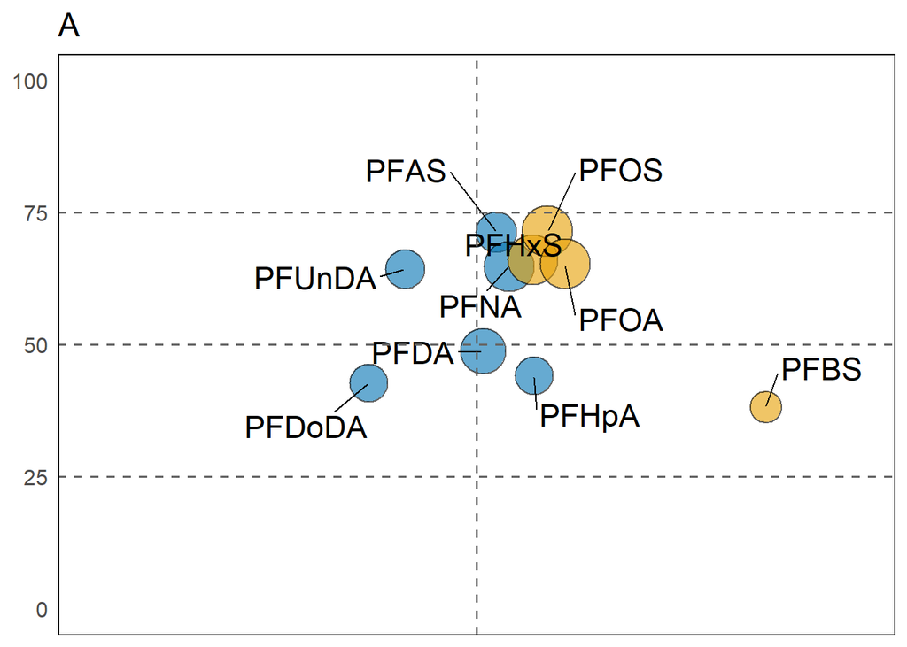

```r
# Run separate meta-analyses for each chemical_id
results_list2 <- map_dfr(chemicals, function(chem) {
  dat_sub <- dat_lnH %>% filter(chemical_id == chem)

  if (n_distinct(dat_sub$ma_e_id) > 1) {  # Require at least 2 meta-analytic estimates
    tryCatch({
      vcv_obj <- build_vcv_from_overlap(
  dat_sub     = dat_sub,
  ps_details  = ps_details,
  id_col      = "ma_e_id",
  vi_col      = "SElnH"
)

VCV_sub  <- vcv_obj$V
dat_sub2 <- vcv_obj$dat_vcv

      model <- rma.mv(yi = lnH,
                      V = VCV_sub,
                      random = list(~1|ma_id,
                                    ~1|ma_e_id),
                      test = "t",
                      sparse = TRUE,
                      data = dat_sub2,
                      control = list(iter.max = 1000, rel.tol = 1e-8))

      # Calculate heterogeneity statistics
      # tau2_raw <- sum(model$sigma2)
      # sigma2_v <- sum(1 / model$vi) * (model$k - 1) / (sum(1 / model$vi)^2 - sum((1 / model$vi)^2))
      # I2_raw <- 100 * (tau2_raw / (tau2_raw + sigma2_v))
      # CV_raw <- sqrt(tau2_raw) / abs(model$b[1,1])

      tibble(
        chemical_id = chem,
        lnH = model$b[1,1],
        ci.lb = model$ci.lb,
        ci.ub = model$ci.ub,
        pval = model$pval,
        # tau2 = tau2_raw,
        # I2 = I2_raw,
        # CV = CV_raw,
        k = nrow(dat_sub),
        n = n_distinct(dat_sub$ma_id)
      )
    }, error = function(e) {
      tibble(chemical_id = chem, lnH = NA, ci.lb = NA, ci.ub = NA, pval = NA,
             #tau2 = NA, I2 = NA, CV = NA,
             k = nrow(dat_sub), n = n_distinct(dat_sub$ma_id))
    })
  } else {
     tibble(chemical_id = chem, lnH = NA, ci.lb = NA, ci.ub = NA, pval = NA,
           #tau2 = NA, I2 = NA, CV = NA,
           k = nrow(dat_sub), n = n_distinct(dat_sub$ma_id))
  }
})
```

*Each estimate is based on a separate meta-analysis for each PFAS chemical.*

## Health Outcome Group

The meta-analyses included in our study pooled data from studies on various types of adverse health outcomes. We grouped these health types into groups: the higher grouping level according to the ICD-11 for Mortality and Morbidity Statistics.

**Question:** What groups of adverse health outcome are significantly associated with PFAS exposure?

Similarly to the previous code, I ran separate multilevel meta-analyses for each health outcome group to assess associations by health outcome. For each group, I filtered the dataset and fitted a random-effects model (with random intercepts for meta-analysis ID and effect size ID) when at least two meta-analytic estimates contributed data. For each health outcome, I estimated the pooled log odds ratio (logOR), its confidence interval, and p-value, recording NA values if model fitting was not possible.

```r
# Get a list of outcome groups
outcomes <- unique(dat_quant$health_outcome_group)

# Loop over each health outcome group
results_health <- map_dfr(outcomes, function(outcome) {
  dat_sub <- dat_quant %>% filter(health_outcome_group == outcome)

  if (n_distinct(dat_sub$ma_e_id) > 1) { # requires at least 2 meta-analytic estimates
    tryCatch({

      # Calculate VCV matrix using shared primary studies
vcv_obj <- build_vcv_from_overlap(
  dat_sub = dat_sub,
  ps_details = ps_details,
  id_col = "ma_e_id",
  vi_col = "se"
)

VCV_sub <- vcv_obj$V
dat_sub2 <- vcv_obj$dat_vcv  # reordered to match VCV

      model <- rma.mv(yi = logOR,
                      V = se^2,
                      random = list(~1|ma_id,
                                    ~1|ma_e_id),
                      test = "t",
                      sparse = TRUE,
                      data = dat_sub2,
                      control = list(iter.max = 1000, rel.tol = 1e-8))

      # Calculate heterogeneity statistics
      # tau2_raw <- sum(model$sigma2)
      # sigma2_v <- sum(1 / model$vi) * (model$k - 1) / (sum(1 / model$vi)^2 - sum((1 / model$vi)^2))
      # I2_raw <- 100 * (tau2_raw / (tau2_raw + sigma2_v))
      # CV_raw <- sqrt(tau2_raw) / abs(model$b[1,1])

      tibble(
        health_outcome_group = outcome,
        logOR = model$b[1,1],
        ci.lb = model$ci.lb,
        ci.ub = model$ci.ub,
        pval = model$pval,
        tval = model$zval,
        df = model$ddf,
        # tau2 = tau2_raw,
        # I2 = I2_raw,
        # CV = CV_raw,
        k = nrow(dat_sub),
        n = n_distinct(dat_sub$ma_id)
      )
    }, error = function(e) {
      tibble(health_outcome_group = outcome, logOR = NA, ci.lb = NA, ci.ub = NA, pval = NA,
             #tau2 = NA, I2 = NA, CV = NA,
             k = nrow(dat_sub), n = n_distinct(dat_sub$ma_id))
    })
  } else {
    tibble(health_outcome_group = outcome, logOR = NA, ci.lb = NA, ci.ub = NA, pval = NA,
             #tau2 = NA, I2 = NA, CV = NA,
             k = nrow(dat_sub), n = n_distinct(dat_sub$ma_id))
  }
})
```

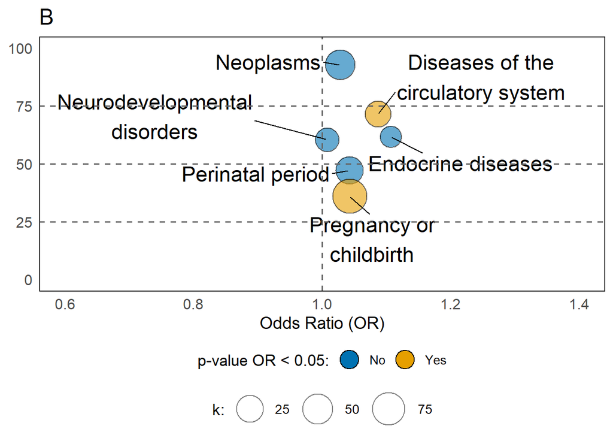

```r
dat_lnH <- dat_lnH %>%
mutate(health_outcome_group = recode(
    health_outcome_group,
    "Endocrine, nutritional or metabolic diseases" = "Endocrine diseases",
    "Diseases of the circulatory system" = "Diseases of the\ncirculatory system",
    "Pregnancy, childbirth or the puerperium" = "Pregnancy or\nchildbirth",
    "Certain conditions originating in the perinatal period" = "Perinatal period",
    "Mental, behavioural or neurodevelopmental disorders" = "Neurodevelopmental\ndisorders",
    "Diseases of the musculoskeletal system or connective tissue" = "Diseases of the\nmusculoskeletal system",
    "Symptoms, signs or clinical findings, not elsewhere classified" = "Symptoms not\nelsewhere classified",
    "Diseases of the respiratory system" = "Diseases of the\nrespiratory system",
    "Diseases of the genitourinary system" = "Diseases of the\ngenitourinary system"
  ))

# Get a list of outcome groups
outcomes <- unique(dat_lnH$health_outcome_group)

# Loop over each health outcome group
results_health_H2 <- map_dfr(outcomes, function(outcome) {
  dat_sub <- dat_lnH %>% filter(health_outcome_group == outcome)

  if (n_distinct(dat_sub$ma_e_id) > 1) { # requires at least 2 meta-analytic estimates
    tryCatch({

      vcv_obj <- build_vcv_from_overlap(
  dat_sub     = dat_sub,
  ps_details  = ps_details,
  id_col      = "ma_e_id",
  vi_col      = "SElnH"
)

VCV_sub  <- vcv_obj$V
dat_sub2 <- vcv_obj$dat_vcv

      model <- rma.mv(yi = lnH,
                      V = VCV_sub,
                      random = list(~1|ma_id,
                                    ~1|ma_e_id),
                      test = "t",
                      sparse = TRUE,
                      data = dat_sub2,
                      control = list(iter.max = 1000, rel.tol = 1e-8))

      # Calculate heterogeneity statistics
      # tau2_raw <- sum(model$sigma2)
      # sigma2_v <- sum(1 / model$vi) * (model$k - 1) / (sum(1 / model$vi)^2 - sum((1 / model$vi)^2))
      # I2_raw <- 100 * (tau2_raw / (tau2_raw + sigma2_v))
      # CV_raw <- sqrt(tau2_raw) / abs(model$b[1,1])

      tibble(
        health_outcome_group = outcome,
        lnH = model$b[1,1],
        ci.lb = model$ci.lb,
        ci.ub = model$ci.ub,
        pval = model$pval,
        # tau2 = tau2_raw,
        # I2 = I2_raw,
        # CV = CV_raw,
        k = nrow(dat_sub),
        n = n_distinct(dat_sub$ma_id)
      )
    }, error = function(e) {
      tibble(health_outcome_group = outcome, lnH = NA, ci.lb = NA, ci.ub = NA, pval = NA,
             #tau2 = NA, I2 = NA, CV = NA,
             k = nrow(dat_sub), n = n_distinct(dat_sub$ma_id))
    })
  } else {
    tibble(health_outcome_group = outcome, lnH = NA, ci.lb = NA, ci.ub = NA, pval = NA,
             #tau2 = NA, I2 = NA, CV = NA,
             k = nrow(dat_sub), n = n_distinct(dat_sub$ma_id))
  }
})
```

# Third Research Question

```r
result_table <- est_dat_merged %>%
  mutate(
    # Create the "Chemical - outcome pair" column
    `Chemical-outcome pair` = paste(chemical_id, "-", health_outcome_group),

    # Format the odds ratio and 95% CI (rounded to 2 decimal places)
    `OR [95% CI]` = sprintf(
      "%.2f [%.2f to %.2f]",
      exp(estimate),
      exp(ci.lb),
      exp(ci.ub)
    ),

    `I²% [95% CI]` = sprintf(
      "%.1f [%.1f to %.1f]",
      I2,
      I2_ci_lower,
      I2_ci_upper
      ),

    # Format the p-value (rounded to 3 decimal places)
    `p value (OR)` = format.pval(pval, digits = 3, eps = 0.001)
  ) %>%

  # Select only the columns we want in the final table
  select(
    `Chemical-outcome pair`,
    `OR [95% CI]`,
    `I²% [95% CI]`,
    `p value (OR)`
  )

# Convert to a flextable
ft <- flextable(result_table) %>%
  theme_zebra() %>%  # Optional: Adds alternating row colors
  autofit()         # Adjusts column widths automatically

ft
```

| Chemical-outcome pair | OR [95% CI] | I²% [95% CI] | p value (OR) |
| --- | --- | --- | --- |
| PFBS - Pregnancy or childbirth | 1.30 [1.06 to 1.61] | NA [NA to NA] | 0.03907 |
| PFDA - Neoplasms | 1.23 [0.79 to 1.92] | 82.2 [0.0 to 98.3] | 0.10742 |
| PFDA - Perinatal period | 1.03 [0.82 to 1.28] | 25.0 [0.0 to 74.0] | 0.42029 |
| PFDA - Pregnancy or childbirth | 1.00 [0.99 to 1.01] | 35.6 [6.2 to 55.7] | 0.59611 |
| PFDoDA - Pregnancy or childbirth | 0.96 [0.09 to 9.64] | NA [NA to NA] | 0.84343 |
| PFHpA - Pregnancy or childbirth | 1.07 [0.62 to 1.86] | 36.1 [0.0 to 65.3] | 0.53373 |
| PFHxS - Diseases of the circulatory system | 1.03 [1.02 to 1.05] | 57.8 [47.1 to 66.4] | 0.01896 |
| PFHxS - Endocrine diseases | 0.99 [0.78 to 1.26] | 51.3 [0.0 to 99.9] | 0.80052 |
| PFHxS - Neoplasms | 1.16 [0.70 to 1.93] | 96.6 [0.0 to 99.9] | 0.42353 |
| PFHxS - Neurodevelopmental disorders | 0.98 [0.79 to 1.22] | 76.7 [0.0 to 100.0] | 0.49474 |
| PFHxS - Perinatal period | 0.98 [0.95 to 1.01] | 19.1 [0.0 to 59.1] | 0.09311 |
| PFHxS - Pregnancy or childbirth | 1.04 [0.99 to 1.10] | 47.1 [18.0 to 65.8] | 0.11189 |
| PFNA - Diseases of the circulatory system | 1.10 [1.01 to 1.19] | 50.4 [22.5 to 68.3] | 0.04215 |
| PFNA - Endocrine diseases | 1.19 [0.47 to 3.04] | 62.4 [0.0 to 100.0] | 0.25061 |
| PFNA - Neoplasms | 0.90 [0.67 to 1.21] | 94.6 [0.0 to 99.9] | 0.28421 |
| PFNA - Neurodevelopmental disorders | 1.00 [0.21 to 4.75] | 42.5 [0.0 to 98.5] | 0.99947 |
| PFNA - Perinatal period | 1.13 [1.02 to 1.26] | 46.2 [0.0 to 75.5] | 0.04067 |
| PFNA - Pregnancy or childbirth | 1.01 [0.93 to 1.10] | 38.7 [22.0 to 51.9] | 0.67150 |
| PFOA - Diseases of the circulatory system | 1.14 [1.08 to 1.21] | 79.9 [14.7 to 95.3] | 0.01345 |
| PFOA - Endocrine diseases | 1.24 [0.65 to 2.38] | 62.6 [0.0 to 87.5] | 0.24438 |
| PFOA - Neoplasms | 1.09 [0.78 to 1.52] | 88.7 [19.3 to 98.4] | 0.42209 |
| PFOA - Neurodevelopmental disorders | 0.98 [0.96 to 1.00] | 61.4 [0.0 to 100.0] | 0.06036 |
| PFOA - Perinatal period | 0.99 [0.87 to 1.13] | 38.5 [0.0 to 62.5] | 0.77588 |
| PFOA - Pregnancy or childbirth | 1.10 [1.02 to 1.18] | 37.7 [9.1 to 57.3] | 0.02166 |
| PFOS - Diseases of the circulatory system | 1.19 [1.04 to 1.36] | 87.6 [16.1 to 98.2] | 0.03331 |
| PFOS - Endocrine diseases | 1.07 [0.19 to 5.89] | 71.7 [0.0 to 99.6] | 0.70583 |
| PFOS - Neoplasms | 1.05 [0.90 to 1.22] | 93.9 [0.0 to 99.8] | 0.31230 |
| PFOS - Neurodevelopmental disorders | 0.97 [0.77 to 1.23] | 46.1 [0.0 to 90.9] | 0.35595 |
| PFOS - Perinatal period | 1.19 [0.88 to 1.60] | 64.5 [33.0 to 81.1] | 0.15006 |
| PFOS - Pregnancy or childbirth | 1.04 [0.98 to 1.09] | 34.1 [18.5 to 46.8] | 0.14447 |
| PFUnDA - Neoplasms | 0.90 [0.32 to 2.52] | 78.4 [0.0 to 96.7] | 0.41522 |
| PFUnDA - Perinatal period | 1.08 [0.06 to 19.84] | 14.6 [0.0 to 74.9] | 0.79626 |
| PFUnDA - Pregnancy or childbirth | 0.87 [0.82 to 0.92] | 53.0 [0.0 to 93.9] | 0.00596 |

# AMSTAR2

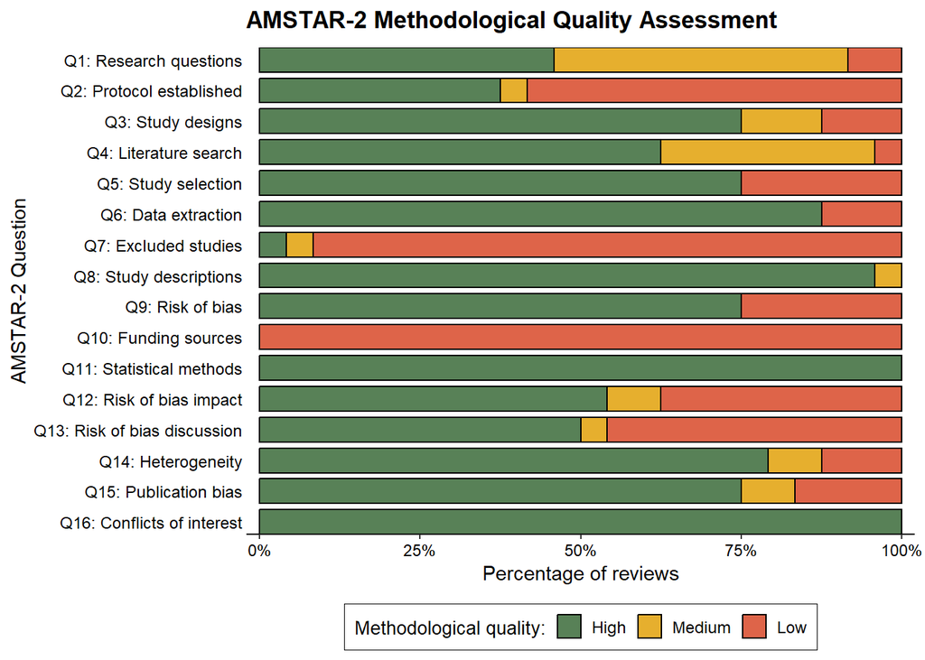

```r
cbp <- c("#588157", "#E6AF2E", "#DE6449", "#B8B8B8")

# Create descriptive question labels (short)
question_labels <- c(
  "Q1: Research questions",
  "Q2: Protocol established",
  "Q3: Study designs",
  "Q4: Literature search",
  "Q5: Study selection",
  "Q6: Data extraction",
  "Q7: Excluded studies",
  "Q8: Study descriptions",
  "Q9: Risk of bias",
  "Q10: Funding sources",
  "Q11: Statistical methods",
  "Q12: Risk of bias impact",
  "Q13: Risk of bias discussion",
  "Q14: Heterogeneity",
  "Q15: Publication bias",
  "Q16: Conflicts of interest"
)

# Transform data to long format and categorize scores
amstar2_long <- amstar2 %>%
  # Convert to long format
  pivot_longer(cols = starts_with("Q"),  # Reshape data from wide to long format
               names_to = "question",
               values_to = "score") %>%
  # Create quality categories
  mutate(
    score_word = case_when(
      score == 1 ~ "High",
      score == 0.5 ~ "Medium",
      score == 0 ~ "Low",
      is.na(score) ~ "NA",
      TRUE ~ "NA"
    ),
    # Create descriptive question labels
    label = factor(question,
                   levels = paste0("Q", 16:1),
                   labels = rev(question_labels))
  ) %>%
  # Remove rows with missing ma_id if any
  filter(!is.na(ma_id))

ggplot(data = amstar2_long) +
  labs(title = expression(bold("AMSTAR-2 Methodological Quality Assessment"))) +
  geom_bar(mapping = aes(x = label,
                         fill = fct_relevel(score_word, c("NA", "Low",
                               "Medium",
                               "High"))),
           alpha = 1,
           width = 0.8,
           size = 0.2,
           position = "fill",
           color = "black") +
  coord_flip(ylim = c(0, 1)) +
  guides(fill = guide_legend(reverse = F)) +
  scale_fill_manual("Methodological quality:",
                    values = cbp,
                    breaks = c("High",
                               "Medium",
                               "Low",
                               "NA")) +
  scale_y_continuous(name = "Percentage of reviews",
                     labels = scales::percent,
                     expand = c(0.02,0)) +
  scale_x_discrete(name = "AMSTAR-2 Question",
                   expand = c(0,0)) +
  theme(axis.title.x = element_text(size = 11),
            axis.title.y = element_text(size = 11),
            axis.ticks.y = element_blank(),
            axis.text.x = element_text(size = 9,
                                       color = "black",
                                       hjust = 0.5),
            axis.text.y = element_text(size = 9,
                                       color = "black",
                                       vjust = 0.5 ),
            axis.line.x = element_line(linewidth = 0.5,
                                       colour = "black",
                                       linetype = "solid"),
            legend.position = "bottom",
            panel.grid.major = element_blank(),
            panel.grid.minor = element_blank(),
            panel.background = element_blank(),
            legend.background = element_rect(linetype = "solid",
                                             colour = "black",
                                             size = 0.2),
            legend.title = element_text(size = 10),
            legend.key.size = unit(0.5, "cm"),
            legend.text = element_text(size = 9))
```

```r
# Function to run sensitivity analysis for one AMSTAR-2 item
run_sensitivity <- function(data, amstar_col, model_name) {

  # Filter out studies with score = 0 for this AMSTAR-2 item
  filtered_data <- data %>%
    filter(!is.na(!!sym(amstar_col)) & !!sym(amstar_col) != 0)

  # Check if enough studies remain
  if(nrow(filtered_data) < 3) {
    return(tibble(
      model = model_name,
      n_studies = nrow(filtered_data),
      estimate = NA,
      se = NA,
      ci_lower = NA,
      ci_upper = NA,
      p_value = NA
    ))
  }

  # Recalculate covariance matrix for filtered data
  VCV_filtered <- impute_covariance_matrix(vi = filtered_data$se^2,
                                          cluster = filtered_data$pair,
                                          r = 0.5)

  # Run the model
  tryCatch({
    mod_sens <- rma.mv(yi = logOR,
                      V = VCV_filtered,
                      random = list(~1|ma_id, ~1|ma_e_id),
                      data = filtered_data,
                      test = "t")

    # Extract results
    tibble(
      model = model_name,
      n_studies = nrow(filtered_data),
      n_excluded = nrow(data) - nrow(filtered_data),
      estimate = as.numeric(mod_sens$beta),
      se = mod_sens$se,
      ci_lower = mod_sens$ci.lb,
      ci_upper = mod_sens$ci.ub,
      p_value = mod_sens$pval
    )
  }, error = function(e) {
    tibble(
      model = model_name,
      n_studies = nrow(filtered_data),
      n_excluded = nrow(data) - nrow(filtered_data),
      estimate = NA,
      se = NA,
      ci_lower = NA,
      ci_upper = NA,
      p_value = NA
    )
  })
}

# Run sensitivity analysis for all AMSTAR-2 items
amstar_cols <- paste0("Q", 1:16)
amstar_labels <- c(
  "Research questions", "Protocol established", "Study designs",
  "Literature search", "Study selection", "Data extraction",
  "Excluded studies", "Study descriptions", "Risk of bias",
  "Funding sources", "Statistical methods", "Risk of bias impact",
  "Risk of bias discussion", "Heterogeneity", "Publication bias",
  "Conflicts of interest"
)

# Run all sensitivity analyses
sensitivity_results <- map2_dfr(amstar_cols, amstar_labels,
                               ~run_sensitivity(dat_quant, .x, .y))
# Add original model results for comparison
original_result <- tibble(
  model = "Original model",
  n_studies = nrow(dat_quant),
  n_excluded = 0,
  estimate = as.numeric(mod_overall$beta),
  se = mod_overall$se,
  ci_lower = mod_overall$ci.lb,
  ci_upper = mod_overall$ci.ub,
  p_value = mod_overall$pval
)

# Combine results and maintain Q1-Q16 order
all_results <- bind_rows(original_result, sensitivity_results) %>%
  mutate(
    model = factor(model, levels = c("Original model", amstar_labels))
  ) %>%
  # Reverse order for plotting (since coord_flip will be used)
  arrange(desc(model))

# Create forest plot
forest_plot <- ggplot(all_results, aes(y = fct_rev(model))) +
  geom_vline(xintercept = 0, linetype = "dashed", color = "gray50") +
  geom_vline(xintercept = original_result$estimate,
             linetype = "solid", color = "red", alpha = 0.7, linewidth = 1) +
  geom_errorbarh(aes(xmin = ci_lower, xmax = ci_upper),
                 height = 0.3, linewidth = 0.8) +
  geom_point(aes(x = estimate), size = 3.5, color = "black") +
  labs(
    title = "Sensitivity Analysis: Effect of Excluding Studies with Low AMSTAR-2 Scores",
    subtitle = "Red vertical line shows original model estimate",
    x = "Log Odds Ratio (95% CI)",
    y = "Excluded AMSTAR-2 Criterion"
  ) +
  theme_minimal() +
  theme(
    axis.text.y = element_text(size = 10),
    axis.text.x = element_text(size = 10),
    plot.title = element_text(size = 12, face = "bold"),
    plot.subtitle = element_text(size = 10, color = "gray40"),
    panel.grid.minor = element_blank(),
    panel.grid.major.y = element_blank()
  )

# Display results
print("Sensitivity Analysis Results:")
```

```
## [1] "Sensitivity Analysis Results:"
```

```r
print(all_results)
```

```
## # A tibble: 17 × 8
##    model        n_studies n_excluded estimate      se ci_lower ci_upper  p_value
##    <fct>            <int>      <dbl>    <dbl>   <dbl>    <dbl>    <dbl>    <dbl>
##  1 Conflicts o…       231          9   0.0459  0.0146  0.0170    0.0748  1.95e-3
##  2 Publication…       203         37   0.0537  0.0163  0.0216    0.0857  1.15e-3
##  3 Heterogenei…       181         59   0.0438  0.0161  0.0121    0.0756  7.14e-3
##  4 Risk of bia…       110        130   0.0560  0.0225  0.0114    0.101   1.44e-2
##  5 Risk of bia…       140        100   0.0534  0.0200  0.0139    0.0930  8.50e-3
##  6 Statistical…       231          9   0.0459  0.0146  0.0170    0.0748  1.95e-3
##  7 Funding sou…         0         NA  NA      NA      NA        NA      NA
##  8 Risk of bias       181         59   0.0308  0.0163 -0.00127   0.0629  5.97e-2
##  9 Study descr…       231          9   0.0459  0.0146  0.0170    0.0748  1.95e-3
## 10 Excluded st…         8        232   0.0313  0.0626 -0.117     0.179   6.32e-1
## 11 Data extrac…       217         23   0.0412  0.0144  0.0129    0.0696  4.56e-3
## 12 Study selec…       183         57   0.0238  0.0157 -0.00710   0.0548  1.30e-1
## 13 Literature …       219         21   0.0450  0.0152  0.0150    0.0749  3.44e-3
## 14 Study desig…       214         26   0.0426  0.0133  0.0163    0.0688  1.60e-3
## 15 Protocol es…        89        151   0.0697  0.0200  0.0299    0.109   7.87e-4
## 16 Research qu…       222         18   0.0323  0.0127  0.00738   0.0573  1.13e-2
## 17 Original mo…       240          0   0.0522  0.0117  0.0291    0.0753  1.32e-5
```

```
## `height` was translated to `width`.
```

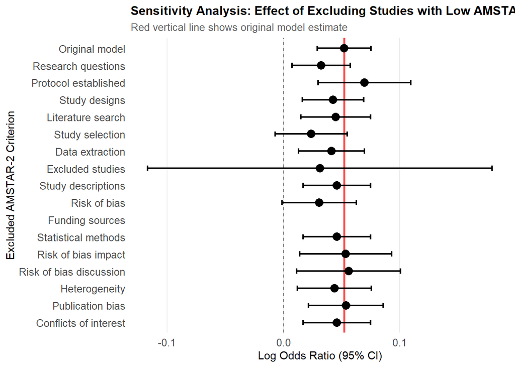

```r
# Prepare table for export
results_table <- all_results %>%
  arrange(match(model, c("Original model", amstar_labels))) %>%
  select(model, n_studies, n_excluded, estimate, ci_lower, ci_upper, p_value) %>%
  mutate(
    estimate = round(estimate, 3),
    ci_lower = round(ci_lower, 3),
    ci_upper = round(ci_upper, 3),
    p_value = round(p_value, 3),
    ci_combined = paste0(estimate, " (", ci_lower, ", ", ci_upper, ")")
  ) %>%
  select(model, n_studies, n_excluded, ci_combined, p_value) %>%
  rename(
    "AMSTAR-2 Criterion" = model,
    "N Studies" = n_studies,
    "N Excluded" = n_excluded,
    "Log OR (95% CI)" = ci_combined,
    "P-value" = p_value
  )

# Create flextable
ft <- flextable(results_table) %>%
  theme_vanilla() %>%
  autofit() %>%
  align(align = "center", part = "all") %>%
  align(j = 1, align = "left", part = "all") %>%
  add_header_lines("AMSTAR-2 Sensitivity Analysis Results") %>%
  fontsize(size = 10, part = "body") %>%
  fontsize(size = 11, part = "header") %>%
  bold(part = "header")

# Save to Word document
doc <- read_docx()
doc <- body_add_flextable(doc, ft)
print(doc, target = here("Rdata/tables", "Supplementary Table 10.docx"))

# Display plot
print(forest_plot)
```

# Sensitivity Analysis

## Leave one out

```
## `height` was translated to `width`.
```

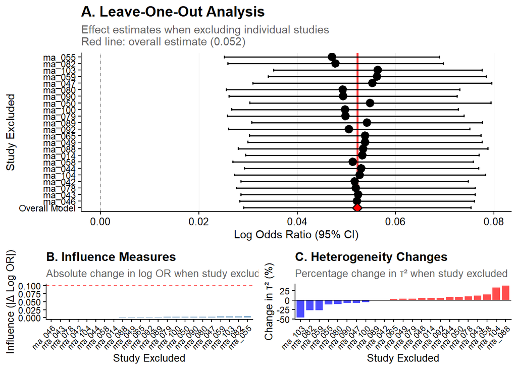

```
## [1] "Leave-One-Out Analysis Results:"
```

```
## # A tibble: 24 × 6
##    excluded_study n_studies estimate ci_lower ci_upper influence
##    <chr>              <int>    <dbl>    <dbl>    <dbl>     <dbl>
##  1 ma_055                NA   0.0470   0.0252   0.0689   0.00516
##  2 ma_082                NA   0.0478   0.0259   0.0697   0.00442
##  3 ma_103                NA   0.0564   0.0352   0.0776   0.00419
##  4 ma_059                NA   0.0563   0.0340   0.0785   0.00406
##  5 ma_047                NA   0.0552   0.0310   0.0795   0.00306
##  6 ma_080                NA   0.0493   0.0256   0.0730   0.00291
##  7 ma_090                NA   0.0493   0.0261   0.0725   0.00289
##  8 ma_050                NA   0.0548   0.0303   0.0794   0.00264
##  9 ma_100                NA   0.0497   0.0267   0.0727   0.00250
## 10 ma_079                NA   0.0498   0.0258   0.0739   0.00237
## # ℹ 14 more rows
```

```
## [1] "Most influential studies (top 5):"
```

```
## # A tibble: 5 × 4
##   excluded_study estimate influence tau2_change
##   <chr>             <dbl>     <dbl>       <dbl>
## 1 ma_055           0.0470   0.00516      -11.5
## 2 ma_082           0.0478   0.00442      -26.7
## 3 ma_103           0.0564   0.00419      -46.5
## 4 ma_059           0.0563   0.00406      -26.6
## 5 ma_047           0.0552   0.00306       -7.05
```

```
##
## Summary of Leave-One-Out Analysis:
```

```
## Range of estimates: 0.047 to 0.056
```

```
## Number of influential studies (influence > 0.1): 0
```

```
## Original estimate: 0.052
```